# Elsevier 2022 SDG mapping

TITLE-ABS("conservation education") AND TITLE-ABS("species")

)

OR

(

AUTHKEY("conservation education") AND AUTHKEY("species")

)

OR TITLE-ABS

(

"Rukia longirostra"

)

OR AUTHKEY

(

"Rukia longirostra"

)

OR TITLE-ABS

(

"penguin conservation"

)

OR AUTHKEY

(

"penguin conservation"

)

OR TITLE-ABS

(

"Tympanuchus cupido attwateri"

)

OR AUTHKEY

(

"Tympanuchus cupido attwateri"

)

OR TITLE-ABS

(

"Coracopsis nigra barklyi"

)

OR AUTHKEY

(

"Coracopsis nigra barklyi"

)

OR TITLE-ABS

(

"Oceanodroma castro"

)

OR AUTHKEY

(

"Oceanodroma castro"

)

OR

(

TITLE-ABS("wolves") AND TITLE-ABS("endangered")

)

OR

(

AUTHKEY("wolves") AND AUTHKEY("endangered")

)

OR TITLE-ABS

(

"Amytornis goyderi"

)

OR AUTHKEY

(

"Amytornis goyderi"

)

OR TITLE-ABS

(

"Cervus nippon kopschi"

)

OR AUTHKEY

(

"Cervus nippon kopschi"

)

OR TITLE-ABS

(

"Glaucomys sabrinus coloratus"

)

OR AUTHKEY

(

"Glaucomys sabrinus coloratus"

)

OR TITLE-ABS

(

"iucn categories"

)

OR AUTHKEY

(

"iucn categories"

)

OR TITLE-ABS

(

"Diceros bicornis"

)

OR AUTHKEY

(

"Diceros bicornis"

)

OR TITLE-ABS

(

"Epicrates subflavus"

)

OR AUTHKEY

(

"Epicrates subflavus"

)

OR TITLE-ABS

(

"Pyrgus ruralis lagunae"

)

OR AUTHKEY

(

"Pyrgus ruralis lagunae"

)

OR TITLE-ABS

(

"Pitta gurneyi"

)

OR AUTHKEY

(

"Pitta gurneyi"

)

OR TITLE-ABS

(

"Mergus octosetaceus"

)

OR AUTHKEY

(

"Mergus octosetaceus"

)

OR TITLE-ABS

(

"Ambystoma macrodactylum croceum"

)

OR AUTHKEY

(

"Ambystoma macrodactylum croceum"

)

OR TITLE-ABS

(

"endangered tropical"

)

OR AUTHKEY

(

"endangered tropical"

)

OR

(

TITLE-ABS("species conservation") AND NOT ((TITLE-ABS("marine") OR TITLE-ABS("marines") OR TITLE-ABS("ocean") OR TITLE-ABS("oceans") OR TITLE-ABS("sea") OR TITLE-ABS("seas")))

)

OR

(

AUTHKEY("species conservation") AND NOT ((AUTHKEY("marine") OR AUTHKEY("marines") OR AUTHKEY("ocean") OR AUTHKEY("oceans") OR AUTHKEY("sea") OR AUTHKEY("seas")))

)

OR TITLE-ABS

(

"Neofelis nebulosa"

)

OR AUTHKEY

(

"Neofelis nebulosa"

)

OR TITLE-ABS

(

"Cyprogenia stegaria"

)

OR AUTHKEY

(

"Cyprogenia stegaria"

)

OR TITLE-ABS

(

"Taurotragus derbianus derbianus"

)

OR AUTHKEY

(

"Taurotragus derbianus derbianus"

)

OR TITLE-ABS

(

"Microtus pennsylvanicus dukecampbelli"

)

OR AUTHKEY

(

"Microtus pennsylvanicus dukecampbelli"

)

OR TITLE-ABS

(

"Crocodylus siamensis"

)

OR AUTHKEY

(

"Crocodylus siamensis"

)

OR TITLE-ABS

(

"Strigops habroptilus"

)

OR AUTHKEY

(

"Strigops habroptilus"

)

OR TITLE-ABS

(

"butterfly conservation"

)

OR AUTHKEY

(

"butterfly conservation"

)

OR TITLE-ABS

(

"Martes flavigula chrysospila"

)

OR AUTHKEY

(

"Martes flavigula chrysospila"

)

OR TITLE-ABS

(

"bear conservation"

)

OR AUTHKEY

(

"bear conservation"

)

OR TITLE-ABS

(

"Antilocapra americana sonoriensis"

)

OR AUTHKEY

(

"Antilocapra americana sonoriensis"

)

OR TITLE-ABS

(

"Copsychus sechellarum"

)

OR AUTHKEY

(

"Copsychus sechellarum"

)

OR TITLE-ABS

(

"Pygathrix nemaeus"

)

OR AUTHKEY

(

"Pygathrix nemaeus"

)

OR TITLE-ABS

(

"Solenodon paradoxus"

)

OR AUTHKEY

(

"Solenodon paradoxus"

)

OR TITLE-ABS

(

"endangered amphibians"

)

OR AUTHKEY

(

"endangered amphibians"

)

OR TITLE-ABS

(

"Gazella dama"

)

OR AUTHKEY

(

"Gazella dama"

)

OR TITLE-ABS

(

"Chlamyphorus truncatus"

)

OR AUTHKEY

(

"Chlamyphorus truncatus"

)

OR TITLE-ABS

(

"Pleurobema georgianum"

)

OR AUTHKEY

(

"Pleurobema georgianum"

)

OR

(

TITLE-ABS("endangered") AND TITLE-ABS("trichechus manatus")

)

OR

(

AUTHKEY("endangered") AND AUTHKEY("trichechus manatus")

)

OR TITLE-ABS

(

"Polyplectron emphanum"

)

OR AUTHKEY

(

"Polyplectron emphanum"

)

OR TITLE-ABS

(

"Grus canadensis nesiotes"

)

OR AUTHKEY

(

"Grus canadensis nesiotes"

)

OR TITLE-ABS

(

"Brachyteles arachnoides"

)

OR AUTHKEY

(

"Brachyteles arachnoides"

)

OR TITLE-ABS

(

"Xyrauchen texanus"

)

OR AUTHKEY

(

"Xyrauchen texanus"

)

OR

(

TITLE-ABS("panthera") AND TITLE-ABS("conservation")

)

OR

(

AUTHKEY("panthera") AND AUTHKEY("conservation")

)

OR TITLE-ABS

(

"Epioblasma triquetra"

)

OR AUTHKEY

(

"Epioblasma triquetra"

)

OR TITLE-ABS

(

"Pseudobulweria macgillivrayi"

)

OR AUTHKEY

(

"Pseudobulweria macgillivrayi"

)

OR TITLE-ABS

(

"Cairina scutulata"

)

OR AUTHKEY

(

"Cairina scutulata"

)

OR

(

TITLE-ABS("Species survival") AND NOT ((TITLE-ABS("marine") OR TITLE-ABS("marines") OR TITLE-ABS("ocean") OR TITLE-ABS("oceans") OR TITLE-ABS("sea") OR TITLE-ABS("seas")))

)

OR

(

AUTHKEY("Species survival") AND NOT ((AUTHKEY("marine") OR AUTHKEY("marines") OR AUTHKEY("ocean") OR AUTHKEY("oceans") OR AUTHKEY("sea") OR AUTHKEY("seas")))

)

OR TITLE-ABS

(

"Pteropus tokudae"

)

OR AUTHKEY

(

"Pteropus tokudae"

)

OR

(

TITLE-ABS("threatened") AND TITLE-ABS("extinction") AND TITLE-ABS("animal")

)

OR

(

AUTHKEY("threatened") AND AUTHKEY("extinction") AND AUTHKEY("animal")

)

OR TITLE-ABS

(

"Fusconaia cuneolus"

)

OR AUTHKEY

(

"Fusconaia cuneolus"

)

OR TITLE-ABS

(

"Ursus arctos pruinosus"

)

OR AUTHKEY

(

"Ursus arctos pruinosus"

)

OR TITLE-ABS

(

"Cercopithecus lhoesti"

)

OR AUTHKEY

(

"Cercopithecus lhoesti"

)

OR TITLE-ABS

(

"Gazella gazella"

)

OR AUTHKEY

(

"Gazella gazella"

)

OR TITLE-ABS

(

"Trichechus inunguis"

)

OR AUTHKEY

(

"Trichechus inunguis"

)

OR TITLE-ABS

(

"Nasalis larvatus"

)

OR AUTHKEY

(

"Nasalis larvatus"

)

OR TITLE-ABS

(

"Neophema chrysogaster"

)

OR AUTHKEY

(

"Neophema chrysogaster"

)

OR TITLE-ABS

(

"Alcelaphus buselaphus swaynei"

)

OR AUTHKEY

(

"Alcelaphus buselaphus swaynei"

)

OR TITLE-ABS

(

"Cyprinodon diabolis"

)

OR AUTHKEY

(

"Cyprinodon diabolis"

)

OR TITLE-ABS

(

"Rhinoceros unicornis"

)

OR AUTHKEY

(

"Rhinoceros unicornis"

)

OR TITLE-ABS

(

"Macropus parma"

)

OR AUTHKEY

(

"Macropus parma"

)

OR TITLE-ABS

(

"Peromyscus polionotus trissyllepsis"

)

OR AUTHKEY

(

"Peromyscus polionotus trissyllepsis"

)

OR TITLE-ABS

(

"Cuon alpinus"

)

OR AUTHKEY

(

"Cuon alpinus"

)

OR

(

(TITLE-ABS("extinction") AND TITLE-ABS("turtles")) AND NOT ((TITLE-ABS("marine") OR TITLE-ABS("marines") OR TITLE-ABS("ocean") OR TITLE-ABS("oceans") OR TITLE-ABS("sea") OR TITLE-ABS("seas")))

)

OR

(

(AUTHKEY("extinction") AND AUTHKEY("turtles")) AND NOT ((AUTHKEY("marine") OR AUTHKEY("marines") OR AUTHKEY("ocean") OR AUTHKEY("oceans") OR AUTHKEY("sea") OR AUTHKEY("seas")))

)

OR TITLE-ABS

(

"tiger conservation"

)

OR AUTHKEY

(

"tiger conservation"

)

OR TITLE-ABS

(

"Trachemys scripta callirostris"

)

OR AUTHKEY

(

"Trachemys scripta callirostris"

)

OR TITLE-ABS

(

"Etheostoma percnurum"

)

OR AUTHKEY

(

"Etheostoma percnurum"

)

OR TITLE-ABS

(

"Brychius hungerfordi"

)

OR AUTHKEY

(

"Brychius hungerfordi"

)

OR TITLE-ABS

(

"Cephalophus jentinki"

)

OR AUTHKEY

(

"Cephalophus jentinki"

)

OR TITLE-ABS

(

"Halcyon cinnamomina cinnamomina"

)

OR AUTHKEY

(

"Halcyon cinnamomina cinnamomina"

)

OR TITLE-ABS

(

"Helminthoglypta walkeriana"

)

OR AUTHKEY

(

"Helminthoglypta walkeriana"

)

OR TITLE-ABS

(

"Oryx leucoryx"

)

OR AUTHKEY

(

"Oryx leucoryx"

)

OR TITLE-ABS

(

"Gambusia nobilis"

)

OR AUTHKEY

(

"Gambusia nobilis"

)

OR TITLE-ABS

(

"endangered frogs"

)

OR AUTHKEY

(

"endangered frogs"

)

OR TITLE-ABS

(

"Pleurobema pyriforme"

)

OR AUTHKEY

(

"Pleurobema pyriforme"

)

OR TITLE-ABS

(

"Cicindela nevadica lincolniana"

)

OR AUTHKEY

(

"Cicindela nevadica lincolniana"

)

OR TITLE-ABS

(

"Lanius ludovicianus mearnsi"

)

OR AUTHKEY

(

"Lanius ludovicianus mearnsi"

)

OR

(

TITLE-ABS("endangered subspecies") AND NOT ((TITLE-ABS("marine") OR TITLE-ABS("marines") OR TITLE-ABS("ocean") OR TITLE-ABS("oceans") OR TITLE-ABS("sea") OR TITLE-ABS("seas")))

)

OR

(

AUTHKEY("endangered subspecies") AND NOT ((AUTHKEY("marine") OR AUTHKEY("marines") OR AUTHKEY("ocean") OR AUTHKEY("oceans") OR AUTHKEY("sea") OR AUTHKEY("seas")))

)

OR TITLE-ABS

(

"Chaeropus ecaudatus"

)

OR AUTHKEY

(

"Chaeropus ecaudatus"

)

OR TITLE-ABS

(

"Anas aucklandica nesiotis"

)

OR AUTHKEY

(

"Anas aucklandica nesiotis"

)

OR

(

TITLE-ABS("species") AND TITLE-ABS("endangered") AND TITLE-ABS("predator") AND (TITLE-ABS("inland") OR TITLE-ABS("terrestrial") OR TITLE-ABS("forest"))

)

OR

(

AUTHKEY("species") AND AUTHKEY("endangered") AND AUTHKEY("predator") AND (AUTHKEY("inland") OR AUTHKEY("terrestrial") OR AUTHKEY("forest"))

)

OR TITLE-ABS

(

"Crax blumenbachii"

)

OR AUTHKEY

(

"Crax blumenbachii"

)

OR TITLE-ABS

(

"Gambusia gaigei"

)

OR AUTHKEY

(

"Gambusia gaigei"

)

OR TITLE-ABS

(

"Sphenodon punctatus"

)

OR AUTHKEY

(

"Sphenodon punctatus"

)

OR TITLE-ABS

(

"Assiminea pecos"

)

OR AUTHKEY

(

"Assiminea pecos"

)

OR

(

(TITLE-ABS("predator-prey interaction") AND (TITLE-ABS("inland") OR TITLE-ABS("terrestrial") OR TITLE-ABS("forest"))) OR (TITLE-ABS("predatorprey interaction") AND (TITLE-ABS("inland") OR TITLE-ABS("terrestrial") OR TITLE-ABS("forest")))

)

OR

(

(AUTHKEY("predator-prey interaction") AND (AUTHKEY("inland") OR AUTHKEY("terrestrial") OR AUTHKEY("forest"))) OR (AUTHKEY("predatorprey interaction") AND (AUTHKEY("inland") OR AUTHKEY("terrestrial") OR AUTHKEY("forest")))

)

OR TITLE-ABS

(

"Pyrrhura cruentata"

)

OR AUTHKEY

(

"Pyrrhura cruentata"

)

OR TITLE-ABS

(

"Sauromalus varius"

)

OR AUTHKEY

(

"Sauromalus varius"

)

OR TITLE-ABS

(

"Geopsittacus occidentalis"

)

OR AUTHKEY

(

"Geopsittacus occidentalis"

)

OR TITLE-ABS

(

"Alligator sinensis"

)

OR AUTHKEY

(

"Alligator sinensis"

)

OR TITLE-ABS

(

"Amazona imperialis"

)

OR AUTHKEY

(

"Amazona imperialis"

)

OR TITLE-ABS

(

"Acipenser transmontanus"

)

OR AUTHKEY

(

"Acipenser transmontanus"

)

OR TITLE-ABS

(

"Cercopithecus diana"

)

OR AUTHKEY

(

"Cercopithecus diana"

)

OR TITLE-ABS

(

"Palmeria dolei"

)

OR AUTHKEY

(

"Palmeria dolei"

)

OR TITLE-ABS

(

"Ovis vignei vignei"

)

OR AUTHKEY

(

"Ovis vignei vignei"

)

OR TITLE-ABS

(

"Lagorchestes hirsutus"

)

OR AUTHKEY

(

"Lagorchestes hirsutus"

)

OR TITLE-ABS

(

"Buteo solitarius"

)

OR AUTHKEY

(

"Buteo solitarius"

)

OR TITLE-ABS

(

"Megalagrion pacificum"

)

OR AUTHKEY

(

"Megalagrion pacificum"

)

OR TITLE-ABS

(

"Pterodroma sandwichensis"

)

OR AUTHKEY

(

"Pterodroma sandwichensis"

)

OR TITLE-ABS

(

"Plethobasus cyphyus"

)

OR AUTHKEY

(

"Plethobasus cyphyus"

)

OR TITLE-ABS

(

"Capra walie"

)

OR AUTHKEY

(

"Capra walie"

)

OR TITLE-ABS

(

"extinction recovery"

)

OR AUTHKEY

(

"extinction recovery"

)

OR TITLE-ABS

(

"Pseudemys alabamensis"

)

OR AUTHKEY

(

"Pseudemys alabamensis"

)

OR TITLE-ABS

(

"Cervus eldi"

)

OR AUTHKEY

(

"Cervus eldi"

)

OR TITLE-ABS

(

"Chasmistes cujus"

)

OR AUTHKEY

(

"Chasmistes cujus"

)

OR TITLE-ABS

(

"Gila purpurea"

)

OR AUTHKEY

(

"Gila purpurea"

)

OR

(

TITLE-ABS("rare species") AND TITLE-ABS("threatened")

)

OR

(

AUTHKEY("rare species") AND AUTHKEY("threatened")

)

OR TITLE-ABS

(

"Morenia ocellata"

)

OR AUTHKEY

(

"Morenia ocellata"

)

OR TITLE-ABS

(

"Phoenicoparrus andinus"

)

OR AUTHKEY

(

"Phoenicoparrus andinus"

)

OR TITLE-ABS

(

"Lophura imperialis"

)

OR AUTHKEY

(

"Lophura imperialis"

)

OR TITLE-ABS

(

"Bettongia gaimardi"

)

OR AUTHKEY

(

"Bettongia gaimardi"

)

OR TITLE-ABS

(

"Ammodorcas clarkei"

)

OR AUTHKEY

(

"Ammodorcas clarkei"

)

OR TITLE-ABS

(

"Planigale ingrami subtilissima"

)

OR AUTHKEY

(

"Planigale ingrami subtilissima"

)

OR TITLE-ABS

(

"Uratelornis chimaera"

)

OR AUTHKEY

(

"Uratelornis chimaera"

)

OR TITLE-ABS

(

"Dipodomys heermanni morroensis"

)

OR AUTHKEY

(

"Dipodomys heermanni morroensis"

)

OR TITLE-ABS

(

"Eurycea sosorum"

)

OR AUTHKEY

(

"Eurycea sosorum"

)

OR TITLE-ABS

(

"Strymon acis bartrami"

)

OR AUTHKEY

(

"Strymon acis bartrami"

)

OR

(

TITLE-ABS("heavily hunted") AND NOT ((TITLE-ABS("marine") OR TITLE-ABS("marines") OR TITLE-ABS("ocean") OR TITLE-ABS("oceans") OR TITLE-ABS("sea") OR TITLE-ABS("seas")))

)

OR

(

AUTHKEY("heavily hunted") AND NOT ((AUTHKEY("marine") OR AUTHKEY("marines") OR AUTHKEY("ocean") OR AUTHKEY("oceans") OR AUTHKEY("sea") OR AUTHKEY("seas")))

)

OR TITLE-ABS

(

"conservation of birds"

)

OR AUTHKEY

(

"conservation of birds"

)

OR TITLE-ABS

(

"Leptoptilos dubius"

)

OR AUTHKEY

(

"Leptoptilos dubius"

)

OR TITLE-ABS

(

"Priodontes maximus"

)

OR AUTHKEY

(

"Priodontes maximus"

)

OR TITLE-ABS

(

"Numenius tenuirostris"

)

OR AUTHKEY

(

"Numenius tenuirostris"

)

OR TITLE-ABS

(

"Panthera leo leo"

)

OR AUTHKEY

(

"Panthera leo leo"

)

OR TITLE-ABS

(

"endangered lizards"

)

OR AUTHKEY

(

"endangered lizards"

)

OR TITLE-ABS

(

"Camarhynchus pauper"

)

OR AUTHKEY

(

"Camarhynchus pauper"

)

OR

(

TITLE-ABS("wolves") AND TITLE-ABS("hunt")

)

OR

(

AUTHKEY("wolves") AND AUTHKEY("hunt")

)

OR TITLE-ABS

(

"Pipile jacutinga"

)

OR AUTHKEY

(

"Pipile jacutinga"

)

OR TITLE-ABS

(

"Corvus kubaryi"

)

OR AUTHKEY

(

"Corvus kubaryi"

)

OR TITLE-ABS

(

"Falco peregrinus peregrinus"

)

OR AUTHKEY

(

"Falco peregrinus peregrinus"

)

OR TITLE-ABS

(

"Saguinus oedipus"

)

OR AUTHKEY

(

"Saguinus oedipus"

)

OR TITLE-ABS

(

"Symphalangus syndactylus"

)

OR AUTHKEY

(

"Symphalangus syndactylus"

)

OR TITLE-ABS

(

"Peromyscus gossypinus allapaticola"

)

OR AUTHKEY

(

"Peromyscus gossypinus allapaticola"

)

OR TITLE-ABS

(

"Picoides borealis"

)

OR AUTHKEY

(

"Picoides borealis"

)

OR TITLE-ABS

(

"Foudia sechellarum"

)

OR AUTHKEY

(

"Foudia sechellarum"

)

OR

(

(TITLE-ABS("biodiversity") AND TITLE-ABS("extinction")) AND NOT ((TITLE-ABS("marine") OR TITLE-ABS("marines") OR TITLE-ABS("ocean") OR TITLE-ABS("oceans") OR TITLE-ABS("sea") OR TITLE-ABS("seas")))

)

OR

(

(AUTHKEY("biodiversity") AND AUTHKEY("extinction")) AND NOT ((AUTHKEY("marine") OR AUTHKEY("marines") OR AUTHKEY("ocean") OR AUTHKEY("oceans") OR AUTHKEY("sea") OR AUTHKEY("seas")))

)

OR

(

TITLE-ABS("Species survival") AND (TITLE-ABS("inland") OR TITLE-ABS("terrestrial") OR TITLE-ABS("forest"))

)

OR

(

AUTHKEY("Species survival") AND (AUTHKEY("inland") OR AUTHKEY("terrestrial") OR AUTHKEY("forest"))

)

OR TITLE-ABS

(

"Pleurobema gibberum"

)

OR AUTHKEY

(

"Pleurobema gibberum"

)

OR TITLE-ABS

(

"Crossoptilon crossoptilon"

)

OR AUTHKEY

(

"Crossoptilon crossoptilon"

)

OR TITLE-ABS

(

"Mimus Graysoni"

)

OR AUTHKEY

(

"Mimus Graysoni"

)

OR TITLE-ABS

(

"Pomarea nigra"

)

OR AUTHKEY

(

"Pomarea nigra"

)

OR TITLE-ABS

(

"Somatochlora hineana"

)

OR AUTHKEY

(

"Somatochlora hineana"

)

OR TITLE-ABS

(

"Bradypus torquatus"

)

OR AUTHKEY

(

"Bradypus torquatus"

)

OR TITLE-ABS

(

"Glaucopsyche lygdamus palosverdesensis"

)

OR AUTHKEY

(

"Glaucopsyche lygdamus palosverdesensis"

)

OR TITLE-ABS

(

"Lophophorus sclateri"

)

OR AUTHKEY

(

"Lophophorus sclateri"

)

OR

(

TITLE-ABS("extinction recovery") AND TITLE-ABS("species")

)

OR

(

AUTHKEY("extinction recovery") AND AUTHKEY("species")

)

OR TITLE-ABS

(

"Pseudocopaeodes eunus obscurus"

)

OR AUTHKEY

(

"Pseudocopaeodes eunus obscurus"

)

OR TITLE-ABS

(

"Callaeas cinerea"

)

OR AUTHKEY

(

"Callaeas cinerea"

)

OR TITLE-ABS

(

"Lemiox rimosus"

)

OR AUTHKEY

(

"Lemiox rimosus"

)

OR TITLE-ABS

(

"Gazella leptoceros"

)

OR AUTHKEY

(

"Gazella leptoceros"

)

OR TITLE-ABS

(

"Sterna antillarum"

)

OR AUTHKEY

(

"Sterna antillarum"

)

OR TITLE-ABS

(

"Icaricia icarioides missionensis"

)

OR AUTHKEY

(

"Icaricia icarioides missionensis"

)

OR TITLE-ABS

(

"Equus hemionus"

)

OR AUTHKEY

(

"Equus hemionus"

)

OR TITLE-ABS

(

"Columba inornata wetmorei"

)

OR AUTHKEY

(

"Columba inornata wetmorei"

)

OR TITLE-ABS

(

"Petrogale xanthopus"

)

OR AUTHKEY

(

"Petrogale xanthopus"

)

OR

(

TITLE-ABS("biodiversity") AND TITLE-ABS("extinction") AND (TITLE-ABS("inland") OR TITLE-ABS("terrestrial") OR TITLE-ABS("forest"))

)

OR

(

AUTHKEY("biodiversity") AND AUTHKEY("extinction") AND (AUTHKEY("inland") OR AUTHKEY("terrestrial") OR AUTHKEY("forest"))

)

OR

(

TITLE-ABS("extinction") AND TITLE-ABS("turtles") AND (TITLE-ABS("inland") OR TITLE-ABS("terrestrial") OR TITLE-ABS("forest"))

)

OR

(

AUTHKEY("extinction") AND AUTHKEY("turtles") AND (AUTHKEY("inland") OR AUTHKEY("terrestrial") OR AUTHKEY("forest"))

)

OR TITLE-ABS

(

"Anolis roosevelti"

)

OR AUTHKEY

(

"Anolis roosevelti"

)

OR TITLE-ABS

(

"Cyprinodon elegans"

)

OR AUTHKEY

(

"Cyprinodon elegans"

)

OR TITLE-ABS

(

"Ara ambiguus"

)

OR AUTHKEY

(

"Ara ambiguus"

)

OR TITLE-ABS

(

"Vicugna vicugna"

)

OR AUTHKEY

(

"Vicugna vicugna"

)

OR TITLE-ABS

(

"Vultur gryphus"

)

OR AUTHKEY

(

"Vultur gryphus"

)

OR TITLE-ABS

(

"Acrocephalus familiaris kingi"

)

OR AUTHKEY

(

"Acrocephalus familiaris kingi"

)

OR TITLE-ABS

(

"Ovis canadensis sierrae"

)

OR AUTHKEY

(

"Ovis canadensis sierrae"

)

OR

(

TITLE-ABS("giant panda") AND TITLE-ABS("conservation")

)

OR

(

AUTHKEY("giant panda") AND AUTHKEY("conservation")

)

OR

(

TITLE-ABS("predator-prey system") OR TITLE-ABS("predatorprey system")

)

OR

(

AUTHKEY("predator-prey system") OR AUTHKEY("predatorprey system")

)

OR TITLE-ABS

(

"Etheostoma akatulo"

)

OR AUTHKEY

(

"Etheostoma akatulo"

)

OR TITLE-ABS

(

"Ducula galeata"

)

OR AUTHKEY

(

"Ducula galeata"

)

OR TITLE-ABS

(

"Chondrohierax uncinatus mirus"

)

OR AUTHKEY

(

"Chondrohierax uncinatus mirus"

)

OR TITLE-ABS

(

"Cicindela ohlone"

)

OR AUTHKEY

(

"Cicindela ohlone"

)

OR TITLE-ABS

(

"Haliaeetus albicilla groenlandicus"

)

OR AUTHKEY

(

"Haliaeetus albicilla groenlandicus"

)

OR TITLE-ABS

(

"Rana muscosa"

)

OR AUTHKEY

(

"Rana muscosa"

)

OR TITLE-ABS

(

"Rhadine persephone"

)

OR AUTHKEY

(

"Rhadine persephone"

)

OR

(

(TITLE-ABS("extinction") AND TITLE-ABS("predation")) AND NOT ((TITLE-ABS("marine") OR TITLE-ABS("marines") OR TITLE-ABS("ocean") OR TITLE-ABS("oceans") OR TITLE-ABS("sea") OR TITLE-ABS("seas")))

)

OR

(

(AUTHKEY("extinction") AND AUTHKEY("predation")) AND NOT ((AUTHKEY("marine") OR AUTHKEY("marines") OR AUTHKEY("ocean") OR AUTHKEY("oceans") OR AUTHKEY("sea") OR AUTHKEY("seas")))

)

OR TITLE-ABS

(

"endangered bird"

)

OR AUTHKEY

(

"endangered bird"

)

OR TITLE-ABS

(

"endangered primate"

)

OR AUTHKEY

(

"endangered primate"

)

OR

(

TITLE-ABS("species") AND TITLE-ABS("endangered") AND TITLE-ABS("predation") AND (TITLE-ABS("inland") OR TITLE-ABS("terrestrial") OR TITLE-ABS("forest"))

)

OR

(

AUTHKEY("species") AND AUTHKEY("endangered") AND AUTHKEY("predation") AND (AUTHKEY("inland") OR AUTHKEY("terrestrial") OR AUTHKEY("forest"))

)

OR TITLE-ABS

(

"Aipysurus fuscus"

)

OR AUTHKEY

(

"Aipysurus fuscus"

)

OR TITLE-ABS

(

"Malimbus ibadanensis"

)

OR AUTHKEY

(

"Malimbus ibadanensis"

)

OR TITLE-ABS

(

"Lycaeides melissa samuelis"

)

OR AUTHKEY

(

"Lycaeides melissa samuelis"

)

OR TITLE-ABS

(

"Pharomachrus mocinno"

)

OR AUTHKEY

(

"Pharomachrus mocinno"

)

OR TITLE-ABS

(

"species threatened"

)

OR AUTHKEY

(

"species threatened"

)

OR TITLE-ABS

(

"Propithecus spp."

)

OR AUTHKEY

(

"Propithecus spp."

)

OR TITLE-ABS

(

"Thinornis novaeseelandiae"

)

OR AUTHKEY

(

"Thinornis novaeseelandiae"

)

OR TITLE-ABS

(

"Gila bicolor snyderi"

)

OR AUTHKEY

(

"Gila bicolor snyderi"

)

OR TITLE-ABS

(

"Cephalorhynchus hectori hectori"

)

OR AUTHKEY

(

"Cephalorhynchus hectori hectori"

)

OR TITLE-ABS

(

"Python molurus molurus"

)

OR AUTHKEY

(

"Python molurus molurus"

)

OR TITLE-ABS

(

"endangered shrub"

)

OR AUTHKEY

(

"endangered shrub"

)

OR TITLE-ABS

(

"Lagostrophus fasciatus"

)

OR AUTHKEY

(

"Lagostrophus fasciatus"

)

OR

(

(TITLE-ABS("species") AND TITLE-ABS("threatened") AND TITLE-ABS("predator")) AND NOT ((TITLE-ABS("marine") OR TITLE-ABS("marines") OR TITLE-ABS("ocean") OR TITLE-ABS("oceans") OR TITLE-ABS("sea") OR TITLE-ABS("seas")))

)

OR

(

(AUTHKEY("species") AND AUTHKEY("threatened") AND AUTHKEY("predator")) AND NOT ((AUTHKEY("marine") OR AUTHKEY("marines") OR AUTHKEY("ocean") OR AUTHKEY("oceans") OR AUTHKEY("sea") OR AUTHKEY("seas")))

)

OR

(

(TITLE-ABS("Predation") AND TITLE-ABS("threat") AND TITLE-ABS("species")) AND NOT ((TITLE-ABS("marine") OR TITLE-ABS("marines") OR TITLE-ABS("ocean") OR TITLE-ABS("oceans") OR TITLE-ABS("sea") OR TITLE-ABS("seas")))

)

OR

(

(AUTHKEY("Predation") AND AUTHKEY("threat") AND AUTHKEY("species")) AND NOT ((AUTHKEY("marine") OR AUTHKEY("marines") OR AUTHKEY("ocean") OR AUTHKEY("oceans") OR AUTHKEY("sea") OR AUTHKEY("seas")))

)

OR TITLE-ABS

(

"Chaetocercus berlepschi"

)

OR AUTHKEY

(

"Chaetocercus berlepschi"

)

OR TITLE-ABS

(

"Canis lupus baileyi"

)

OR AUTHKEY

(

"Canis lupus baileyi"

)

OR TITLE-ABS

(

"Grus vipio"

)

OR AUTHKEY

(

"Grus vipio"

)

OR TITLE-ABS

(

"Cacajao spp."

)

OR AUTHKEY

(

"Cacajao spp."

)

OR TITLE-ABS

(

"Alouatta palliata"

)

OR AUTHKEY

(

"Alouatta palliata"

)

OR TITLE-ABS

(

"Hippocamelus antisensis"

)

OR AUTHKEY

(

"Hippocamelus antisensis"

)

OR

(

TITLE-ABS("extinction") AND TITLE-ABS("predation") AND (TITLE-ABS("inland") OR TITLE-ABS("terrestrial") OR TITLE-ABS("forest"))

)

OR

(

AUTHKEY("extinction") AND AUTHKEY("predation") AND (AUTHKEY("inland") OR AUTHKEY("terrestrial") OR AUTHKEY("forest"))

)

OR TITLE-ABS

(

"extinction and recovery"

)

OR AUTHKEY

(

"extinction and recovery"

)

OR TITLE-ABS

(

"Cercopithecus erythrogaster"

)

OR AUTHKEY

(

"Cercopithecus erythrogaster"

)

OR TITLE-ABS

(

"Oxyloma haydeni kanabensis"

)

OR AUTHKEY

(

"Oxyloma haydeni kanabensis"

)

OR TITLE-ABS

(

"Pleurobema clava"

)

OR AUTHKEY

(

"Pleurobema clava"

)

OR TITLE-ABS

(

"amphibians conservation"

)

OR AUTHKEY

(

"amphibians conservation"

)

OR TITLE-ABS

(

"threatened butterflies"

)

OR AUTHKEY

(

"threatened butterflies"

)

OR TITLE-ABS

(

"Pteronura brasiliensis"

)

OR AUTHKEY

(

"Pteronura brasiliensis"

)

OR

(

TITLE-ABS("ratio-dependent predator-prey") OR TITLE-ABS("ratiodependent predatorprey")

)

OR

(

AUTHKEY("ratio-dependent predator-prey") OR AUTHKEY("ratiodependent predatorprey")

)

OR TITLE-ABS

(

"Bos javanicus"

)

OR AUTHKEY

(

"Bos javanicus"

)

OR TITLE-ABS

(

"Caprimulgus noctitherus"

)

OR AUTHKEY

(

"Caprimulgus noctitherus"

)

OR TITLE-ABS

(

"Lophura swinhoii"

)

OR AUTHKEY

(

"Lophura swinhoii"

)

OR TITLE-ABS

(

"Ammodramus maritimus mirabilis"

)

OR AUTHKEY

(

"Ammodramus maritimus mirabilis"

)

OR TITLE-ABS

(

"Dipodomys ingens"

)

OR AUTHKEY

(

"Dipodomys ingens"

)

OR

(

(TITLE-ABS("captive breeding") AND TITLE-ABS("status of")) AND NOT ((TITLE-ABS("marine") OR TITLE-ABS("marines") OR TITLE-ABS("ocean") OR TITLE-ABS("oceans") OR TITLE-ABS("sea") OR TITLE-ABS("seas")))

)

OR

(

(AUTHKEY("captive breeding") AND AUTHKEY("status of")) AND NOT ((AUTHKEY("marine") OR AUTHKEY("marines") OR AUTHKEY("ocean") OR AUTHKEY("oceans") OR AUTHKEY("sea") OR AUTHKEY("seas")))

)

OR

(

TITLE-ABS("extinction") AND TITLE-ABS("species") AND (TITLE-ABS("terrestrial") OR TITLE-ABS("inland") OR TITLE-ABS("forest"))

)

OR

(

AUTHKEY("extinction") AND AUTHKEY("species") AND (AUTHKEY("terrestrial") OR AUTHKEY("inland") OR AUTHKEY("forest"))

)

OR TITLE-ABS

(

"Tapirus indicus"

)

OR AUTHKEY

(

"Tapirus indicus"

)

OR TITLE-ABS

(

"Achatinella spp."

)

OR AUTHKEY

(

"Achatinella spp."

)

OR TITLE-ABS

(

"Pan paniscus"

)

OR AUTHKEY

(

"Pan paniscus"

)

OR TITLE-ABS

(

"Crocodylus acutus"

)

OR AUTHKEY

(

"Crocodylus acutus"

)

OR TITLE-ABS

(

"Epicrates inornatus"

)

OR AUTHKEY

(

"Epicrates inornatus"

)

OR TITLE-ABS

(

"Babyrousa babyrussa"

)

OR AUTHKEY

(

"Babyrousa babyrussa"

)

OR

(

TITLE-ABS("wolves") AND TITLE-ABS("extinction")

)

OR

(

AUTHKEY("wolves") AND AUTHKEY("extinction")

)

OR TITLE-ABS

(

"Phytotoma raimondii"

)

OR AUTHKEY

(

"Phytotoma raimondii"

)

OR TITLE-ABS

(

"Paroreomyza maculata"

)

OR AUTHKEY

(

"Paroreomyza maculata"

)

OR TITLE-ABS

(

"Planigale tenuirostris"

)

OR AUTHKEY

(

"Planigale tenuirostris"

)

OR TITLE-ABS

(

"Romerolagus diazi"

)

OR AUTHKEY

(

"Romerolagus diazi"

)

OR TITLE-ABS

(

"Saiga tatarica mongolica"

)

OR AUTHKEY

(

"Saiga tatarica mongolica"

)

OR TITLE-ABS

(

"Eurycea waterlooensis"

)

OR AUTHKEY

(

"Eurycea waterlooensis"

)

OR TITLE-ABS

(

"Troglodytes aedon mesoleucus"

)

OR AUTHKEY

(

"Troglodytes aedon mesoleucus"

)

OR TITLE-ABS

(

"Hybognathus amarus"

)

OR AUTHKEY

(

"Hybognathus amarus"

)

OR TITLE-ABS

(

"Melanochelys tricarinata"

)

OR AUTHKEY

(

"Melanochelys tricarinata"

)

OR TITLE-ABS

(

"conservation of bats"

)

OR AUTHKEY

(

"conservation of bats"

)

OR TITLE-ABS

(

"threatened flora"

)

OR AUTHKEY

(

"threatened flora"

)

OR TITLE-ABS

(

"Panthera tigris"

)

OR AUTHKEY

(

"Panthera tigris"

)

OR TITLE-ABS

(

"Prionodon pardicolor"

)

OR AUTHKEY

(

"Prionodon pardicolor"

)

OR TITLE-ABS

(

"Corvus leucognaphalus"

)

OR AUTHKEY

(

"Corvus leucognaphalus"

)

OR

(

TITLE-ABS("predicting extinction") AND TITLE-ABS("species")

)

OR

(

AUTHKEY("predicting extinction") AND AUTHKEY("species")

)

OR TITLE-ABS

(

"Chiropotes albinasus"

)

OR AUTHKEY

(

"Chiropotes albinasus"

)

OR TITLE-ABS

(

"iucn criteria"

)

OR AUTHKEY

(

"iucn criteria"

)

OR TITLE-ABS

(

"Rhodonessa caryophyllacea"

)

OR AUTHKEY

(

"Rhodonessa caryophyllacea"

)

OR TITLE-ABS

(

"Hemignathus wilsoni"

)

OR AUTHKEY

(

"Hemignathus wilsoni"

)

OR TITLE-ABS

(

"Margaritifera marrianae"

)

OR AUTHKEY

(

"Margaritifera marrianae"

)

OR TITLE-ABS

(

"Conolophus pallidus"

)

OR AUTHKEY

(

"Conolophus pallidus"

)

OR TITLE-ABS

(

"Potamilus capax"

)

OR AUTHKEY

(

"Potamilus capax"

)

OR TITLE-ABS

(

"Grallaria milleri"

)

OR AUTHKEY

(

"Grallaria milleri"

)

OR TITLE-ABS

(

"Sminthopsis psammophila"

)

OR AUTHKEY

(

"Sminthopsis psammophila"

)

OR TITLE-ABS

(

"animal conservation"

)

OR AUTHKEY

(

"animal conservation"

)

OR

(

TITLE-ABS("threatened species") AND (TITLE-ABS("terrestrial") OR TITLE-ABS("inland") OR TITLE-ABS("freshwater"))

)

OR

(

AUTHKEY("threatened species") AND (AUTHKEY("terrestrial") OR AUTHKEY("inland") OR AUTHKEY("freshwater"))

)

OR TITLE-ABS

(

"Cervus elaphus corsicanus"

)

OR AUTHKEY

(

"Cervus elaphus corsicanus"

)

OR TITLE-ABS

(

"Lasmigona decorata"

)

OR AUTHKEY

(

"Lasmigona decorata"

)

OR TITLE-ABS

(

"Eumops floridanus"

)

OR AUTHKEY

(

"Eumops floridanus"

)

OR TITLE-ABS

(

"Dipodomys nitratoides nitratoides"

)

OR AUTHKEY

(

"Dipodomys nitratoides nitratoides"

)

OR TITLE-ABS

(

"faunal extinction"

)

OR AUTHKEY

(

"faunal extinction"

)

OR TITLE-ABS

(

"Tragopan caboti"

)

OR AUTHKEY

(

"Tragopan caboti"

)

OR TITLE-ABS

(

"Zyzomys pedunculatus"

)

OR AUTHKEY

(

"Zyzomys pedunculatus"

)

OR TITLE-ABS

(

"Egretta eulophotes"

)

OR AUTHKEY

(

"Egretta eulophotes"

)

OR TITLE-ABS

(

"Ursus arctos"

)

OR AUTHKEY

(

"Ursus arctos"

)

OR TITLE-ABS

(

"Crocodylus porosus"

)

OR AUTHKEY

(

"Crocodylus porosus"

)

OR

(

TITLE-ABS("critically endanger") AND TITLE-ABS("species")

)

OR

(

AUTHKEY("critically endanger") AND AUTHKEY("species")

)

OR TITLE-ABS

(

"endangered freshwater"

)

OR AUTHKEY

(

"endangered freshwater"

)

OR TITLE-ABS

(

"Cyprinodon nevadensis pectoralis"

)

OR AUTHKEY

(

"Cyprinodon nevadensis pectoralis"

)

OR TITLE-ABS

(

"Fulica americana alai"

)

OR AUTHKEY

(

"Fulica americana alai"

)

OR TITLE-ABS

(

"Chrysocyon brachyurus"

)

OR AUTHKEY

(

"Chrysocyon brachyurus"

)

OR

(

(TITLE-ABS("risk of extinction") AND TITLE-ABS("species")) AND NOT ((TITLE-ABS("marine") OR TITLE-ABS("marines") OR TITLE-ABS("ocean") OR TITLE-ABS("oceans") OR TITLE-ABS("sea") OR TITLE-ABS("seas")))

)

OR

(

(AUTHKEY("risk of extinction") AND AUTHKEY("species")) AND NOT ((AUTHKEY("marine") OR AUTHKEY("marines") OR AUTHKEY("ocean") OR AUTHKEY("oceans") OR AUTHKEY("sea") OR AUTHKEY("seas")))

)

OR TITLE-ABS

(

"Medionidus simpsonianus"

)

OR AUTHKEY

(

"Medionidus simpsonianus"

)

OR TITLE-ABS

(

"Cnemidophorus vanzoi"

)

OR AUTHKEY

(

"Cnemidophorus vanzoi"

)

OR TITLE-ABS

(

"Brachylophus fasciatus"

)

OR AUTHKEY

(

"Brachylophus fasciatus"

)

OR TITLE-ABS

(

"Varanus komodoensis"

)

OR AUTHKEY

(

"Varanus komodoensis"

)

OR TITLE-ABS

(

"Xeromys myoides"

)

OR AUTHKEY

(

"Xeromys myoides"

)

OR TITLE-ABS

(

"Pleurobema decisum"

)

OR AUTHKEY

(

"Pleurobema decisum"

)

OR TITLE-ABS

(

"Crystallaria cincotta"

)

OR AUTHKEY

(

"Crystallaria cincotta"

)

OR TITLE-ABS

(

"Gavialis gangeticus"

)

OR AUTHKEY

(

"Gavialis gangeticus"

)

OR TITLE-ABS

(

"Myrmecobius fasciatus"

)

OR AUTHKEY

(

"Myrmecobius fasciatus"

)

OR TITLE-ABS

(

"endangered animal"

)

OR AUTHKEY

(

"endangered animal"

)

OR TITLE-ABS

(

"Gallotia simonyi simonyi"

)

OR AUTHKEY

(

"Gallotia simonyi simonyi"

)

OR TITLE-ABS

(

"Terrapene coahuila"

)

OR AUTHKEY

(

"Terrapene coahuila"

)

OR

(

(TITLE-ABS("IUCN") AND TITLE-ABS("species")) AND NOT ((TITLE-ABS("marine") OR TITLE-ABS("marines") OR TITLE-ABS("ocean") OR TITLE-ABS("oceans") OR TITLE-ABS("sea") OR TITLE-ABS("seas")))

)

OR

(

(AUTHKEY("IUCN") AND AUTHKEY("species")) AND NOT ((AUTHKEY("marine") OR AUTHKEY("marines") OR AUTHKEY("ocean") OR AUTHKEY("oceans") OR AUTHKEY("sea") OR AUTHKEY("seas")))

)

OR TITLE-ABS

(

"Tomistoma schlegelii"

)

OR AUTHKEY

(

"Tomistoma schlegelii"

)

OR TITLE-ABS

(

"Bufo periglenes"

)

OR AUTHKEY

(

"Bufo periglenes"

)

OR

(

TITLE-ABS("predator-prey model") OR TITLE-ABS("predatorprey model")

)

OR

(

AUTHKEY("predator-prey model") OR AUTHKEY("predatorprey model")

)

OR

(

TITLE-ABS("extinction probability") AND TITLE-ABS("species") AND (TITLE-ABS("inland") OR TITLE-ABS("terrestrial") OR TITLE-ABS("forest"))

)

OR

(

AUTHKEY("extinction probability") AND AUTHKEY("species") AND (AUTHKEY("inland") OR AUTHKEY("terrestrial") OR AUTHKEY("forest"))

)

OR TITLE-ABS

(

"mammal extinction"

)

OR AUTHKEY

(

"mammal extinction"

)

OR TITLE-ABS

(

"Oreophasis derbianus"

)

OR AUTHKEY

(

"Oreophasis derbianus"

)

OR TITLE-ABS

(

"Alasmidonta raveneliana"

)

OR AUTHKEY

(

"Alasmidonta raveneliana"

)

OR TITLE-ABS

(

"Psittacula echo"

)

OR AUTHKEY

(

"Psittacula echo"

)

OR TITLE-ABS

(

"Vireo bellii pusillus"

)

OR AUTHKEY

(

"Vireo bellii pusillus"

)

OR

(

TITLE-ABS("canis lupus") AND NOT ((TITLE-ABS("familiaris") OR TITLE-ABS("dog") OR TITLE-ABS("dogs")))

)

OR

(

AUTHKEY("canis lupus") AND NOT ((AUTHKEY("familiaris") OR AUTHKEY("dog") OR AUTHKEY("dogs")))

)

OR TITLE-ABS

(

"Villosa perpurpurea"

)

OR AUTHKEY

(

"Villosa perpurpurea"

)

OR TITLE-ABS

(

"Lampsilis subangulata"

)

OR AUTHKEY

(

"Lampsilis subangulata"

)

OR TITLE-ABS

(

"Apodemia mormo langei"

)

OR AUTHKEY

(

"Apodemia mormo langei"

)

OR TITLE-ABS

(

"Etheostoma nuchale"

)

OR AUTHKEY

(

"Etheostoma nuchale"

)

OR TITLE-ABS

(

"Reithrodontomys raviventris"

)

OR AUTHKEY

(

"Reithrodontomys raviventris"

)

OR TITLE-ABS

(

"endangered butterflies"

)

OR AUTHKEY

(

"endangered butterflies"

)

OR TITLE-ABS

(

"Nicrophorus americanus"

)

OR AUTHKEY

(

"Nicrophorus americanus"

)

OR TITLE-ABS

(

"Gymnomyza samoensis"

)

OR AUTHKEY

(

"Gymnomyza samoensis"

)

OR TITLE-ABS

(

"Falco araea"

)

OR AUTHKEY

(

"Falco araea"

)

OR TITLE-ABS

(

"Buteo galapagoensis"

)

OR AUTHKEY

(

"Buteo galapagoensis"

)

OR

(

(TITLE-ABS("species") AND TITLE-ABS("endangered") AND TITLE-ABS("predator")) AND NOT ((TITLE-ABS("marine") OR TITLE-ABS("marines") OR TITLE-ABS("ocean") OR TITLE-ABS("oceans") OR TITLE-ABS("sea") OR TITLE-ABS("seas")))

)

OR

(

(AUTHKEY("species") AND AUTHKEY("endangered") AND AUTHKEY("predator")) AND NOT ((AUTHKEY("marine") OR AUTHKEY("marines") OR AUTHKEY("ocean") OR AUTHKEY("oceans") OR AUTHKEY("sea") OR AUTHKEY("seas")))

)

OR TITLE-ABS

(

"Myadestes palmeri"

)

OR AUTHKEY

(

"Myadestes palmeri"

)

OR TITLE-ABS

(

"birds conservation"

)

OR AUTHKEY

(

"birds conservation"

)

OR TITLE-ABS

(

"Cyclura pinguis"

)

OR AUTHKEY

(

"Cyclura pinguis"

)

OR TITLE-ABS

(

"Cercocebus galeritus galeritus"

)

OR AUTHKEY

(

"Cercocebus galeritus galeritus"

)

OR TITLE-ABS

(

"Pyriglena atra"

)

OR AUTHKEY

(

"Pyriglena atra"

)

OR TITLE-ABS

(

"Lampsilis higginsii"

)

OR AUTHKEY

(

"Lampsilis higginsii"

)

OR

(

(TITLE-ABS("overhunting") AND TITLE-ABS("conservation")) AND NOT ((TITLE-ABS("marine") OR TITLE-ABS("marines") OR TITLE-ABS("ocean") OR TITLE-ABS("oceans") OR TITLE-ABS("sea") OR TITLE-ABS("seas")))

)

OR

(

(AUTHKEY("overhunting") AND AUTHKEY("conservation")) AND NOT ((AUTHKEY("marine") OR AUTHKEY("marines") OR AUTHKEY("ocean") OR AUTHKEY("oceans") OR AUTHKEY("sea") OR AUTHKEY("seas")))

)

OR TITLE-ABS

(

"Leptodea leptodon"

)

OR AUTHKEY

(

"Leptodea leptodon"

)

OR TITLE-ABS

(

"Hippotragus niger variani"

)

OR AUTHKEY

(

"Hippotragus niger variani"

)

OR TITLE-ABS

(

"Loxops coccineus"

)

OR AUTHKEY

(

"Loxops coccineus"

)

OR TITLE-ABS

(

"Anaea troglodyta floridalis"

)

OR AUTHKEY

(

"Anaea troglodyta floridalis"

)

OR TITLE-ABS

(

"Pezoporus wallicus"

)

OR AUTHKEY

(

"Pezoporus wallicus"

)

OR TITLE-ABS

(

"Psephotus pulcherrimus"

)

OR AUTHKEY

(

"Psephotus pulcherrimus"

)

OR TITLE-ABS

(

"Onychogalea fraenata"

)

OR AUTHKEY

(

"Onychogalea fraenata"

)

OR TITLE-ABS

(

"Odontophorus strophium"

)

OR AUTHKEY

(

"Odontophorus strophium"

)

OR TITLE-ABS

(

"threatened medicinal plant"

)

OR AUTHKEY

(

"threatened medicinal plant"

)

OR TITLE-ABS

(

"Penelope perspicax"

)

OR AUTHKEY

(

"Penelope perspicax"

)

OR TITLE-ABS

(

"Pterodroma madeira"

)

OR AUTHKEY

(

"Pterodroma madeira"

)

OR

(

(TITLE-ABS("threatened") AND TITLE-ABS("extinction") AND TITLE-ABS("species")) AND NOT ((TITLE-ABS("marine") OR TITLE-ABS("marines") OR TITLE-ABS("ocean") OR TITLE-ABS("oceans") OR TITLE-ABS("sea") OR TITLE-ABS("seas")))

)

OR

(

(AUTHKEY("threatened") AND AUTHKEY("extinction") AND AUTHKEY("species")) AND NOT ((AUTHKEY("marine") OR AUTHKEY("marines") OR AUTHKEY("ocean") OR AUTHKEY("oceans") OR AUTHKEY("sea") OR AUTHKEY("seas")))

)

OR

(

TITLE-ABS("endangered plant") AND TITLE-ABS("species")

)

OR

(

AUTHKEY("endangered plant") AND AUTHKEY("species")

)

OR

(

TITLE-ABS("rare species") AND TITLE-ABS("threat")

)

OR

(

AUTHKEY("rare species") AND AUTHKEY("threat")

)

OR

(

TITLE-ABS("predator-prey dynamic") OR TITLE-ABS("predatorprey dynamic")

)

OR

(

AUTHKEY("predator-prey dynamic") OR AUTHKEY("predatorprey dynamic")

)

OR TITLE-ABS

(

"Acipenser sinensis"

)

OR AUTHKEY

(

"Acipenser sinensis"

)

OR

(

TITLE-ABS("recovery plan") AND TITLE-ABS("species")

)

OR

(

AUTHKEY("recovery plan") AND AUTHKEY("species")

)

OR TITLE-ABS

(

"endangered orchids"

)

OR AUTHKEY

(

"endangered orchids"

)

OR

(

TITLE-ABS("threatened") AND TITLE-ABS("extinction") AND TITLE-ABS("species") AND (TITLE-ABS("inland") OR TITLE-ABS("terrestrial") OR TITLE-ABS("forest"))

)

OR

(

AUTHKEY("threatened") AND AUTHKEY("extinction") AND AUTHKEY("species") AND (AUTHKEY("inland") OR AUTHKEY("terrestrial") OR AUTHKEY("forest"))

)

OR TITLE-ABS

(

"Amazona brasiliensis"

)

OR AUTHKEY

(

"Amazona brasiliensis"

)

OR TITLE-ABS

(

"Megalagrion nigrohamatum nigrolineatum"

)

OR AUTHKEY

(

"Megalagrion nigrohamatum nigrolineatum"

)

OR

(

TITLE-ABS("turtle conservation") AND NOT ((TITLE-ABS("marine") OR TITLE-ABS("marines") OR TITLE-ABS("ocean") OR TITLE-ABS("oceans") OR TITLE-ABS("sea") OR TITLE-ABS("seas")))

)

OR

(

AUTHKEY("turtle conservation") AND NOT ((AUTHKEY("marine") OR AUTHKEY("marines") OR AUTHKEY("ocean") OR AUTHKEY("oceans") OR AUTHKEY("sea") OR AUTHKEY("seas")))

)

OR

(

TITLE-ABS("conservation of biodiversity") AND NOT ((TITLE-ABS("marine") OR TITLE-ABS("marines") OR TITLE-ABS("ocean") OR TITLE-ABS("oceans") OR TITLE-ABS("sea") OR TITLE-ABS("seas")))

)

OR

(

AUTHKEY("conservation of biodiversity") AND NOT ((AUTHKEY("marine") OR AUTHKEY("marines") OR AUTHKEY("ocean") OR AUTHKEY("oceans") OR AUTHKEY("sea") OR AUTHKEY("seas")))

)

OR TITLE-ABS

(

"Euphydryas editha quino"

)

OR AUTHKEY

(

"Euphydryas editha quino"

)

OR TITLE-ABS

(

"Caiman crocodilus apaporiensis"

)

OR AUTHKEY

(

"Caiman crocodilus apaporiensis"

)

OR TITLE-ABS

(

"amphibian conservation"

)

OR AUTHKEY

(

"amphibian conservation"

)

OR TITLE-ABS

(

"Acipenser mikadoi"

)

OR AUTHKEY

(

"Acipenser mikadoi"

)

OR

(

TITLE-ABS("extinction") AND (TITLE-ABS("predator") OR TITLE-ABS("prey") OR TITLE-ABS("predators") OR TITLE-ABS("preys")) AND (TITLE-ABS("inland") OR TITLE-ABS("terrestrial") OR TITLE-ABS("forest"))

)

OR

(

AUTHKEY("extinction") AND (AUTHKEY("predator") OR AUTHKEY("prey") OR AUTHKEY("predators") OR AUTHKEY("preys")) AND (AUTHKEY("inland") OR AUTHKEY("terrestrial") OR AUTHKEY("forest"))

)

OR TITLE-ABS

(

"Moho braccatus"

)

OR AUTHKEY

(

"Moho braccatus"

)

OR TITLE-ABS

(

"Empetrichthys latos"

)

OR AUTHKEY

(

"Empetrichthys latos"

)

OR

(

TITLE-ABS("panthera") AND TITLE-ABS("endangered")

)

OR

(

AUTHKEY("panthera") AND AUTHKEY("endangered")

)

OR TITLE-ABS

(

"Epioblasma obliquata perobliqua"

)

OR AUTHKEY

(

"Epioblasma obliquata perobliqua"

)

OR TITLE-ABS

(

"Tamiasciurus hudsonicus grahamensis"

)

OR AUTHKEY

(

"Tamiasciurus hudsonicus grahamensis"

)

OR TITLE-ABS

(

"Typhlomolge rathbuni"

)

OR AUTHKEY

(

"Typhlomolge rathbuni"

)

OR TITLE-ABS

(

"Leucopsar rothschildi"

)

OR AUTHKEY

(

"Leucopsar rothschildi"

)

OR TITLE-ABS

(

"Amazona vittata"

)

OR AUTHKEY

(

"Amazona vittata"

)

OR TITLE-ABS

(

"Dendroica kirtlandii"

)

OR AUTHKEY

(

"Dendroica kirtlandii"

)

OR TITLE-ABS

(

"Dinacoma caseyi"

)

OR AUTHKEY

(

"Dinacoma caseyi"

)

OR TITLE-ABS

(

"Ambystoma tigrinum stebbinsi"

)

OR AUTHKEY

(

"Ambystoma tigrinum stebbinsi"

)

OR TITLE-ABS

(

"Cervus elaphus wallichi"

)

OR AUTHKEY

(

"Cervus elaphus wallichi"

)

OR TITLE-ABS

(

"Papilio hospiton"

)

OR AUTHKEY

(

"Papilio hospiton"

)

OR TITLE-ABS

(

"Campephilus imperialis"

)

OR AUTHKEY

(

"Campephilus imperialis"

)

OR TITLE-ABS

(

"Microhexura montivaga"

)

OR AUTHKEY

(

"Microhexura montivaga"

)

OR TITLE-ABS

(

"Epioblasma brevidens"

)

OR AUTHKEY

(

"Epioblasma brevidens"

)

OR TITLE-ABS

(

"Sylvilagus bachmani riparius"

)

OR AUTHKEY

(

"Sylvilagus bachmani riparius"

)

OR TITLE-ABS

(

"endangered medicinal herb"

)

OR AUTHKEY

(

"endangered medicinal herb"

)

OR TITLE-ABS

(

"Gila elegans"

)

OR AUTHKEY

(

"Gila elegans"

)

)

)

OR

(

(

TITLE-ABS

(

"mining and deforestation"

)

OR AUTHKEY

(

"mining and deforestation"

)

OR TITLE-ABS

(

"deforestation monitoring"

)

OR AUTHKEY

(

"deforestation monitoring"

)

OR TITLE-ABS

(

"response to deforestation"

)

OR AUTHKEY

(

"response to deforestation"

)

OR TITLE-ABS

(

"deforestation assessment"

)

OR AUTHKEY

(

"deforestation assessment"

)

OR TITLE-ABS

(

"deforestation detection"

)

OR AUTHKEY

(

"deforestation detection"

)

OR TITLE-ABS

(

"deforestation risks"

)

OR AUTHKEY

(

"deforestation risks"

)

OR

(

TITLE-ABS

(

"forest law"

)

AND

(

TITLE-ABS("deforestation") OR TITLE-ABS("forest degradation") OR TITLE-ABS("logging") OR TITLE-ABS("forest loss") OR TITLE-ABS("degradation of forest")

)

)

OR

(

AUTHKEY

(

"forest law"

)

AND

(

AUTHKEY("deforestation") OR AUTHKEY("forest degradation") OR AUTHKEY("logging") OR AUTHKEY("forest loss") OR AUTHKEY("degradation of forest")

)

)

OR

(

(

TITLE-ABS("forest policy") OR TITLE-ABS("forest policies")

)

AND

(

TITLE-ABS("deforestation") OR TITLE-ABS("forest loss") OR TITLE-ABS("loss or forest") OR TITLE-ABS("forest degradation") OR TITLE-ABS("degradation of forest")

)

)

OR

(

(

AUTHKEY("forest policy") OR AUTHKEY("forest policies")

)

AND

(

AUTHKEY("deforestation") OR AUTHKEY("forest loss") OR AUTHKEY("loss or forest") OR AUTHKEY("forest degradation") OR AUTHKEY("degradation of forest")

)

)

OR

(

TITLE-ABS

(

"REDD+"

)

OR TITLE-ABS

(

" reducing emissions from deforestation"

)

OR TITLE-ABS

(

"forest certification"

)

OR TITLE-ABS

(

"reduced emissions from deforestation"

)

)

OR

(

AUTHKEY

(

"REDD+"

)

OR AUTHKEY

(

" reducing emissions from deforestation"

)

OR AUTHKEY

(

"forest certification"

)

OR AUTHKEY

(

"reduced emissions from deforestation"

)

)

OR TITLE-ABS

(

"deforestation control"

)

OR AUTHKEY

(

"deforestation control"

)

OR TITLE-ABS

(

"deforestation drivers"

)

OR AUTHKEY

(

"deforestation drivers"

)

OR TITLE-ABS

(

"deforestation analysis"

)

OR AUTHKEY

(

"deforestation analysis"

)

OR

(

TITLE-ABS

(

"REDD"

)

AND TITLE-ABS

(

"forest degradation"

)

)

OR

(

AUTHKEY

(

"REDD"

)

AND AUTHKEY

(

"forest degradation"

)

)

OR TITLE-ABS

(

"deforestation modelling"

)

OR AUTHKEY

(

"deforestation modelling"

)

OR TITLE-ABS

(

"deforestation policy"

)

OR AUTHKEY

(

"deforestation policy"

)

OR TITLE-ABS

(

"deforestation commitments"

)

OR AUTHKEY

(

"deforestation commitments"

)

OR TITLE-ABS

(

"deforestation risk"

)

OR AUTHKEY

(

"deforestation risk"

)

OR TITLE-ABS

(

"deforestation monitoring"

)

OR AUTHKEY

(

"deforestation monitoring"

)

OR TITLE-ABS

(

"deforestation reduction"

)

OR AUTHKEY

(

"deforestation reduction"

)

OR TITLE-ABS

(

"drivers of deforestation"

)

OR AUTHKEY

(

"drivers of deforestation"

)

OR TITLE-ABS

(

"halt forest degradation"

)

OR AUTHKEY

(

"halt forest degradation"

)

OR TITLE-ABS

(

"reduced emissions from deforestation"

)

OR AUTHKEY

(

"reduced emissions from deforestation"

)

OR TITLE-ABS

(

"halt* deforest*"

)

OR AUTHKEY

(

"halt* deforest*"

)

OR TITLE-ABS

(

"slow deforestation"

)

OR AUTHKEY

(

"slow deforestation"

)

OR

(

TITLE-ABS

(

"agricultural expansion"

)

AND

(

TITLE-ABS("deforestation") OR TITLE-ABS("forest loss") OR TITLE-ABS("loss of forest") OR TITLE-ABS("forest degradation") OR TITLE-ABS("degradation of forest")

)

)

OR

(

AUTHKEY

(

"agricultural expansion"

)

AND

(

AUTHKEY("deforestation") OR AUTHKEY("forest loss") OR AUTHKEY("loss of forest") OR AUTHKEY("forest degradation") OR AUTHKEY("degradation of forest")

)

)

OR TITLE-ABS

(

"agents of deforestation"

)

OR AUTHKEY

(

"agents of deforestation"

)

OR TITLE-ABS

(

"reduce* deforest*"

)

OR AUTHKEY

(

"reduce* deforest*"

)

OR TITLE-ABS

(

"Forest Law Enforcement"

)

OR AUTHKEY

(

"Forest Law Enforcement"

)

OR TITLE-ABS

(

"flegt"

)

OR AUTHKEY

(

"flegt"

)

OR TITLE-ABS

(

"reduction of deforestation"

)

OR AUTHKEY

(

"reduction of deforestation"

)

OR TITLE-ABS

(

"reduce forest degradation"

)

OR AUTHKEY

(

"reduce forest degradation"

)

OR

(

TITLE-ABS

(

"deforestation"

)

AND TITLE-ABS

(

"farming"

)

)

OR

(

AUTHKEY

(

"deforestation"

)

AND AUTHKEY

(

"farming"

)

)

OR TITLE-ABS

(

"reducing emissions from deforestation"

)

OR AUTHKEY

(

"reducing emissions from deforestation"

)

OR TITLE-ABS

(

"causes of deforestation"

)

OR AUTHKEY

(

"causes of deforestation"

)

OR TITLE-ABS

(

"avoided deforestation"

)

OR AUTHKEY

(

"avoided deforestation"

)

OR TITLE-ABS

(

"causes of deforestation"

)

OR AUTHKEY

(

"causes of deforestation"

)

OR TITLE-ABS

(

"combat deforestation"

)

OR AUTHKEY

(

"combat deforestation"

)

)

)

## Subfields of science

In this section, we show how the publication set, captured by the query above, relates to the [Science-Metrix classification system](https://science-metrix.com/?q=en/classification)

As shown in figure 1, the publications related to this publication set fall mainly under the subfields of Ecology (120,279 publications), Forestry (35,243), and Environmental Sciences (34,105). Percentages alongside each subfield indicate the total share of each subfield included under the publication set.

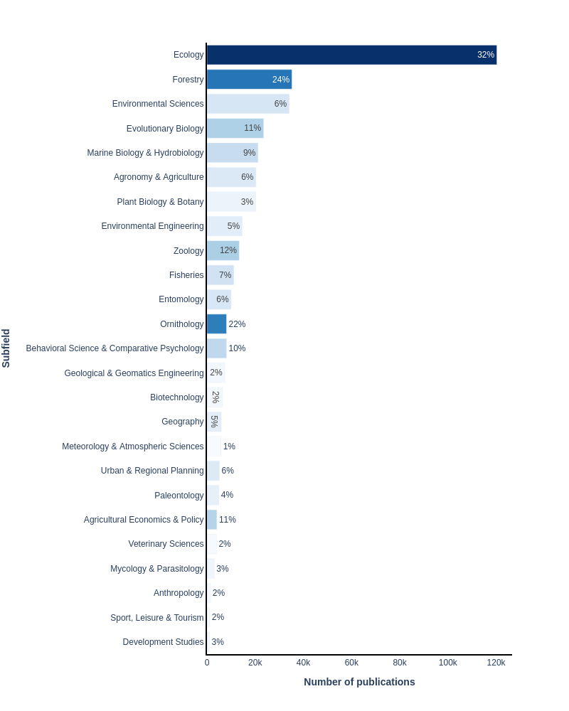

## Journals

In this section, we show how the publication set, captured by the query above, relates to scholarly journals. Journals are sorted in terms of their relevance using term frequency-inverse document frequency (TF-IDF). The horizontal bars are proportional to the number of publications contributed by the journal to the current publication set. The number alongside the horizontal bar is the proportion of the journal contributing to this publication set.

The articles on this topic are published most frequently in the following journals: *Forest Ecology and Management* (7,199 publications), *PLoS ONE* (6,624), and *Biological Conservation* (5,940).

Note, larger journals may not appear in the table below, as their SDG contribution may be relatively small compared to the size of the journal.

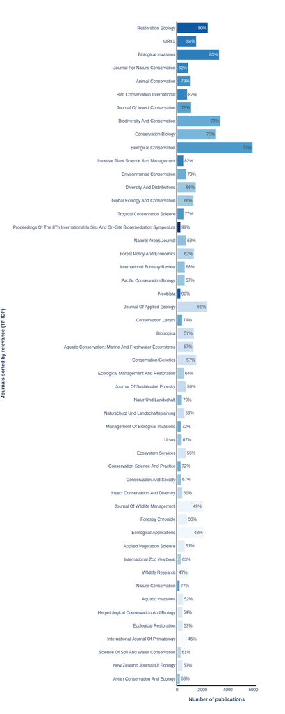

Figure 2. Top 50 journals, in terms of relevance (TF-IDF), for this publication set.

## Keywords

Elsevier’s [Scopus](https://www.scopus.com/search/form.uri?display=basic#basic) database of scientific literature, was used for the table below. The document types included in the data sets are journal articles, reviews, short surveys and conference papers, covering the period 1996–2022. We refer to these documents collectively as “publications” or “papers”.

In order to help better illustrate the content of this set of publications, indicators associated with the keywords most specific to this set (according to a TF-IDF score) are presented below.

|  | Term | # of papers with this term in the publication set | # of papers with this term in all of Scopus | Relevance (TF-IDF) | Percentage of Scopus |
| --- | --- | --- | --- | --- | --- |
| 1 | vegetation restoration | 2741 | 2951 | 18.7637 | 93 |
| 2 | society for ecological restoration | 1040 | 1070 | 18.7541 | 97 |
| 3 | invasive plant species | 1743 | 1906 | 18.7376 | 91 |
| 4 | forest restoration | 2924 | 3185 | 18.7344 | 92 |
| 5 | invasive pest | 2127 | 2367 | 18.7125 | 90 |
| 6 | natura 2000 | 2519 | 2796 | 18.7118 | 90 |
| 7 | plant invasions | 1637 | 1814 | 18.7078 | 90 |
| 8 | vegetation recovery | 1494 | 1652 | 18.7012 | 90 |
| 9 | redd+ | 1865 | 2085 | 18.701 | 89 |
| 10 | plant invasion | 3114 | 3440 | 18.6988 | 91 |

[output cut: 990 more lines]